# TeoNAM STAM — MLM (Family + K) GWAS with candidate genes + coverage sweep [118K panel]

## Composite (A: JLM lollipop · B: MLM authentic 118K · C: MLM FSFHap ancestry-imputed)

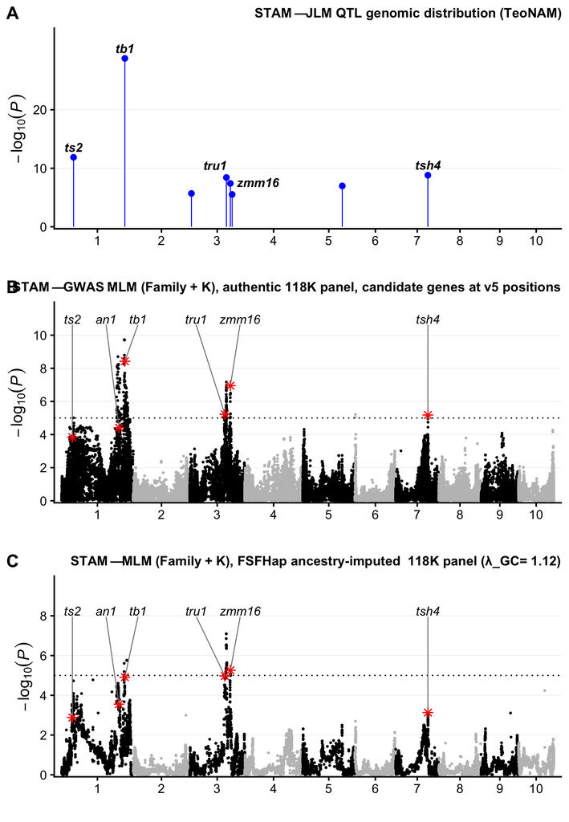

```r
fsf <- fread(here("data/teonam/stam_gwas_mlm_fsfhap_118k.csv"))
lgc_fsf <- lambda_gc(fsf$P)
p_anc <- plot_stam_manhattan(
  fsf,
  sprintf("STAM — MLM (Family + K), FSFHap ancestry-imputed 118K panel (λ_GC = %.2f)", lgc_fsf),
  here("results/sim/teonam/stam_gwas_mlm_fsfhap_manhattan_118k.png")
)
composite <- cowplot::plot_grid(
  p_lolli, p_mlm, p_anc,
  ncol = 1, labels = c("A", "B", "C"), label_size = 20, align = "v", axis = "lr"
)
ggsave(here("results/sim/teonam/stam_composite_mlm_118k.png"), composite, width = 9, height = 13, dpi = 200, bg = "white")
composite
```

## RTIGER ancestry × coverage under MLM (degradation sweep)

The RTIGER coverage sweep under the MLM (Family+K). Reads are Poisson-sampled from the **authentic 118K per-SNP genotypes** over `λ ∈ {0.1, 0.2, 0.5, 1, 5, 10, 20, ∞}×`; RTIGER infers ancestry **directly on all 118K markers, per chromosome** (no thinning, no back-projection), and the per-coverage GL-dosage null (its honest Family+K at that depth) is applied. λ = ∞ is RTIGER’s deterministic ceiling. Compute: `scripts/teonam_rtiger_sweep_118k.R` (writes the OLS and `_mlm` sweep CSVs); this chunk plots.

**Rigidity.** RTIGER’s `rigidity` is a *marker-count* minimum-segment length. The calibrated `rigidity_star = 2` over-segments ~5–6× on this dense grid; a cM-distance rule fails too because the interpolated cM map is heavily tied (median gap ≈ 0). So rigidity is calibrated **empirically on the full grid** — chr1, one family, λ=∞, swept against the FSFHap truth breakpoint density (`agent/rtiger_rigsweep_chr1.R`): **rigidity = 60** reproduces FSFHap’s ~10.4 breakpoints/chr1 (recovered 10.6). That truth-matched segmentation is what makes the profile below smooth rather than the earlier over-segmented sawtooth.

The coverage order is **inverted** relative to OLS: low coverage rides *highest*, ∞ *lowest*. At shallow depth the GL-dosage K is too noisy to correct structure, so the ancestry-confounded QTL leaks through; at ∞ the kinship is well-estimated and crushes it. The chr3 broad 0.1× elevation is a low-coverage MLM artifact (poor K + block recovery in the pericentromere). One replicate per cell.

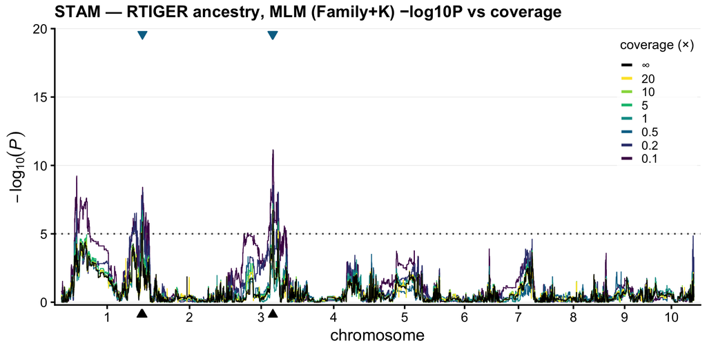

```r
p_sweep <- plot_sweep_line(
  here("results/sim/teonam/stam_gwas_rtiger_118k_mlm_sweep.csv"),
  "STAM — RTIGER ancestry, MLM (Family+K) −log10P vs coverage",
  base_size = 15
)
ggsave(here("results/sim/teonam/stam_gwas_rtiger_118k_mlm_sweep_manhattan.png"), p_sweep, width = 9, height = 4.6, dpi = 200, bg = "white")
p_sweep
```